# Analyzing Individual BGG Users

Phil Henrickson

2022-01-01

# **mathyvds’s** BoardGameGeek Collection

This notebook contains a set of analyses for the selected user’s boardgamegeek collection. The bulk of the analysis is focused on building a user-specific predictive model to predict the games that mathyvds is likely to own. This enables to ask questions like, based on the games the user currently owns, what games are a good fit for their collection? What upcoming games are they likely to purchase?

This analysis is based on data from BoardGameGeek that was last updated on **2021-12-20.**

# 1 Collection Overview

We can look at a basic description of the number of games that the user owns, has rated, has previously owned, etc.

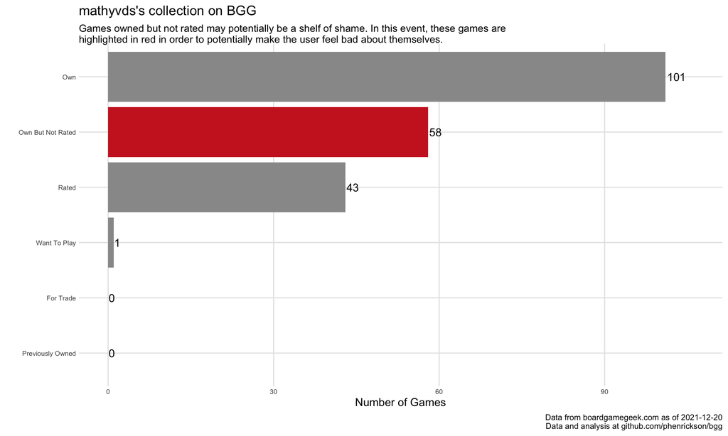

What years has the user owned/rated games from? While we can’t see when a user added or removed a game from their collection, we can look at their collection by the years in which their games were published.

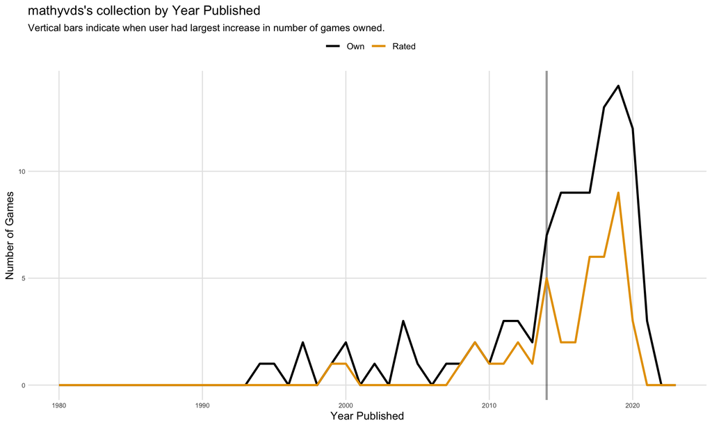

## 1.1 What types of games does mathyvds own?

We can look at the most frequent types of categories, mechanics, designers, and artists that appear in a user’s collection.

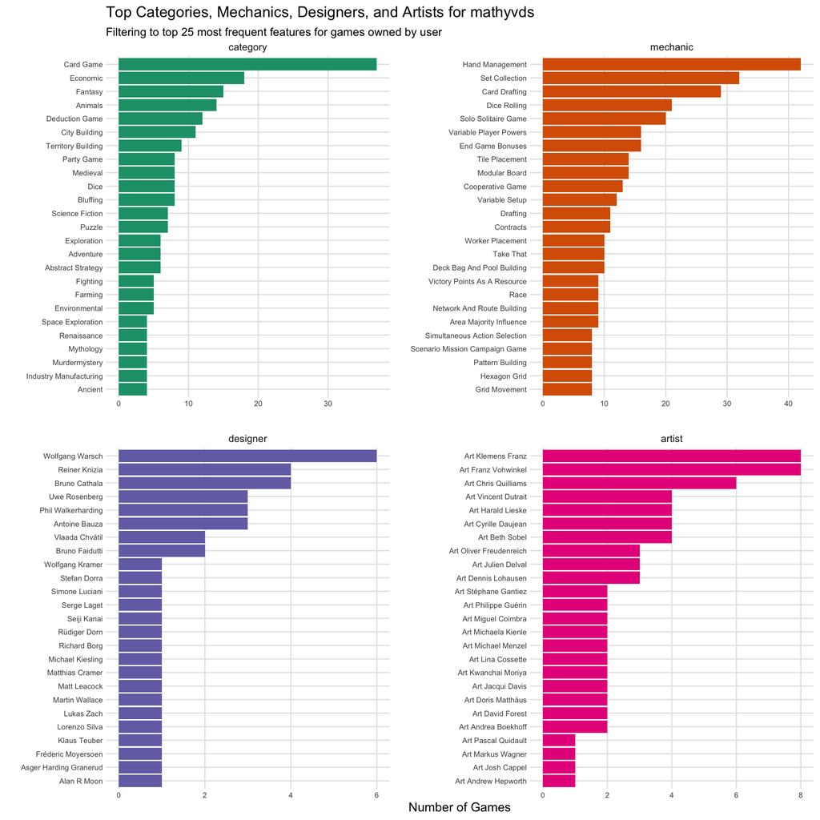

# 2 Modeling **mathyvds’s** Collection

| username | dataset | period | games_owned | games_rated | games_played |
| --- | --- | --- | --- | --- | --- |
| mathyvds | training | published before 2020 | 86 | 40 | 86 |
| mathyvds | test | published 2020 or later | 15 | 3 | 15 |

There are two main (binary) outcomes we will be modeling for the user.

The first, **own** refers to whether the user currently lists a game as owned in their collection. The second, **played** refers to whether the user currently owns, has rated, or previously owned a game. This means the latter will generally have a larger list of games, but may still be a useful category to examine for people who play lots of games without necessarily owning them.

We will train predictive models to learn the probability that the user will own or play individual games based on their features.

## 2.1 Coefficients for mathyvds

We can examine coefficients from the trained modes, which are penalized logistic regressions fit to our two main outcomes. Positive values indicate that a feature increases a user’s probabilility of owning/rating a game, while negative values indicate a feature decreases the probability.

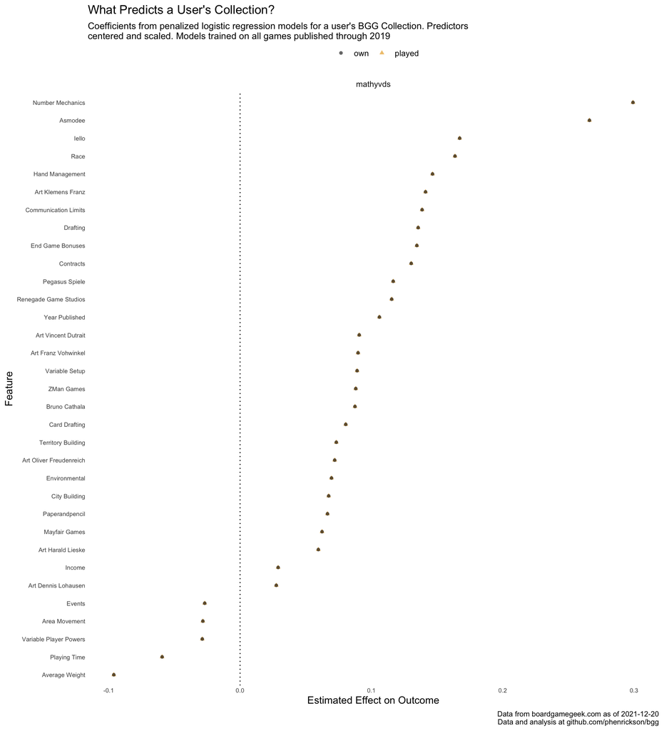

## 2.2 Visualizing Predictors for mathyvds’s Collection

Why did the model identify these features? We can make density plots of the important features for predicting whether the user owned a game. Blue indicates the density for games owned by the user, while grey indicates the density for games not owned by the user.

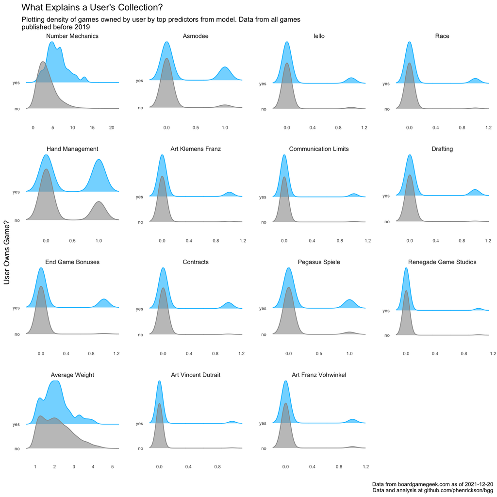

Binary predictors can be difficult to see with this visualization, so we can also directly examine the percentage of games in a user’s collection with a predictor vs the percentage of all games with that predictor.

| username | Feature | % of Games with Feature In_Collection | % of Games with Feature All_Games | Ratio |
| --- | --- | --- | --- | --- |
| mathyvds | End Game Bonuses | 17.4% | 1.1% | 15.6 |
| mathyvds | Contracts | 12.8% | 0.9% | 14.0 |
| mathyvds | Drafting | 12.8% | 0.9% | 13.8 |
| mathyvds | Income | 8.1% | 0.7% | 12.5 |
| mathyvds | Communication Limits | 7.0% | 0.9% | 7.4 |
| mathyvds | Variable Setup | 12.8% | 1.8% | 7.2 |
| mathyvds | Race | 10.5% | 1.8% | 5.8 |
| mathyvds | Renegade Game Studios | 4.7% | 0.9% | 5.4 |
| mathyvds | Environmental | 5.8% | 1.1% | 5.4 |
| mathyvds | Asmodee | 25.6% | 5.2% | 4.9 |
| mathyvds | Iello | 11.6% | 3.1% | 3.8 |
| mathyvds | Pegasus Spiele | 17.4% | 4.7% | 3.7 |
| mathyvds | Mayfair Games | 8.1% | 2.3% | 3.5 |
| mathyvds | ZMan Games | 11.6% | 3.5% | 3.4 |
| mathyvds | Alderac Entertainment Group | 4.7% | 1.5% | 3.0 |
| mathyvds | Territory Building | 10.5% | 3.6% | 2.9 |
| mathyvds | City Building | 11.6% | 4.2% | 2.8 |
| mathyvds | Card Drafting | 30.2% | 11.7% | 2.6 |
| mathyvds | Paperandpencil | 5.8% | 2.7% | 2.2 |
| mathyvds | Hand Management | 46.5% | 26.6% | 1.8 |
| mathyvds | Variable Player Powers | 16.3% | 17.1% | 1.0 |
| mathyvds | Events | 1.2% | 2.0% | 0.6 |
| mathyvds | Area Movement | 2.3% | 6.5% | 0.4 |
| mathyvds | Pickup And Deliver | 1.2% | 3.6% | 0.3 |
| mathyvds | Pirates | 0.0% | 1.8% | 0.0 |

# 3 Assess Model’s Performance on Training Set

Before predicting games in upcoming years, we can examine how well the model did and what games it liked in the training set. In this case, we used resampling techniques (cross validation) to ensure that the model had not seen a game before making its predictions.

## 3.1 Separation Plot

An easy way to examine the performance of classification model is to view a separation plot. We plot the predicted probabilities from the model for every game (from resampling) from lowest to highest. We then overlay a blue line for any game that the user does own. A good classifier is one that is able to *separate* the blue (games owned by the user) from the white (games not owned by the user), with most of the blue occurring at the highest probabilities (right side of the chart).

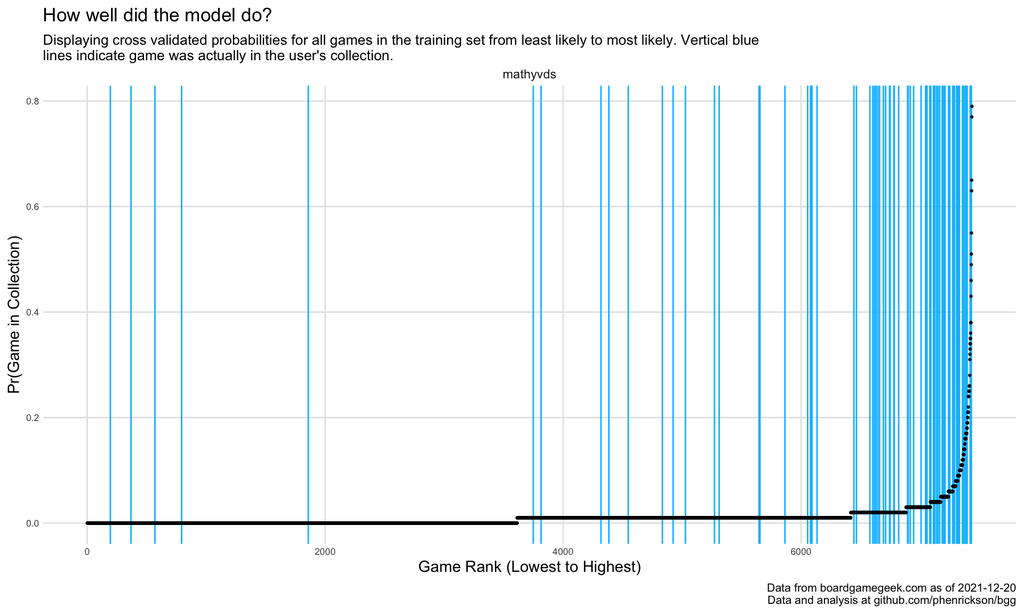

## 3.2 Top Games for **mathyvds** from Training Set

We can display this information in table form, displaying the 100 games with the highest probability of ownership, adding a blue line when the user does own the game.

| username | yearpublished | game_id | name | pred_played | pred_own | actual_played | actual_own |
| --- | --- | --- | --- | --- | --- | --- | --- |
| mathyvds | 2018 | 244711 | Newton | 0.79 | 0.79 | 0 | 0 |
| mathyvds | 2019 | 283863 | The Magnificent | 0.77 | 0.77 | 0 | 0 |
| mathyvds | 2018 | 258444 | Gingerbread House | 0.65 | 0.65 | 0 | 0 |
| mathyvds | 2018 | 205896 | Rising Sun | 0.63 | 0.63 | 0 | 0 |
| mathyvds | 2019 | 276025 | Maracaibo | 0.55 | 0.55 | 0 | 0 |
| mathyvds | 2011 | 70919 | Takenoko | 0.51 | 0.51 | 1 | 1 |
| mathyvds | 2019 | 266507 | Clank!: Legacy – Acquisitions Incorporated | 0.49 | 0.49 | 0 | 0 |
| mathyvds | 2019 | 260710 | Amul | 0.46 | 0.46 | 0 | 0 |
| mathyvds | 2015 | 171623 | The Voyages of Marco Polo | 0.43 | 0.43 | 0 | 0 |
| mathyvds | 2017 | 174430 | Gloomhaven | 0.38 | 0.38 | 0 | 0 |
| mathyvds | 2019 | 253185 | Chai | 0.38 | 0.38 | 0 | 0 |
| mathyvds | 2005 | 18258 | Mission: Red Planet | 0.36 | 0.36 | 0 | 0 |
| mathyvds | 2014 | 163412 | Patchwork | 0.35 | 0.35 | 1 | 1 |
| mathyvds | 2017 | 217861 | Paper Tales | 0.35 | 0.35 | 0 | 0 |
| mathyvds | 2014 | 148228 | Splendor | 0.34 | 0.34 | 1 | 1 |
| mathyvds | 2015 | 182874 | Grand Austria Hotel | 0.34 | 0.34 | 1 | 1 |
| mathyvds | 2014 | 154203 | Imperial Settlers | 0.33 | 0.33 | 0 | 0 |
| mathyvds | 2008 | 34635 | Stone Age | 0.32 | 0.32 | 0 | 0 |
| mathyvds | 2019 | 251247 | Barrage | 0.31 | 0.31 | 0 | 0 |
| mathyvds | 2015 | 181304 | Mysterium | 0.28 | 0.28 | 0 | 0 |
| mathyvds | 2009 | 39683 | At the Gates of Loyang | 0.26 | 0.26 | 0 | 0 |
| mathyvds | 2000 | 478 | Citadels | 0.26 | 0.26 | 0 | 0 |
| mathyvds | 2013 | 140620 | Lewis & Clark: The Expedition | 0.26 | 0.26 | 0 | 0 |
| mathyvds | 2017 | 231280 | Harvest Dice | 0.25 | 0.25 | 0 | 0 |
| mathyvds | 2015 | 175878 | 504 | 0.25 | 0.25 | 0 | 0 |
| mathyvds | 2004 | 12942 | No Thanks! | 0.25 | 0.25 | 0 | 0 |
| mathyvds | 2011 | 103686 | Mundus Novus | 0.25 | 0.25 | 0 | 0 |
| mathyvds | 2017 | 184921 | Bunny Kingdom | 0.24 | 0.24 | 0 | 0 |
| mathyvds | 2018 | 225694 | Decrypto | 0.24 | 0.24 | 0 | 0 |
| mathyvds | 2014 | 156129 | Deception: Murder in Hong Kong | 0.24 | 0.24 | 0 | 0 |

[output cut: 70 more lines]

We can also more formally assess how well the model did in resampling by looking at the area under the receiver operating characteristic. A perfect model would receive a score of 1, while a model that cannot predict the outcome will default to a score of 0.5. The extent to which something is a *good* score depends on the setting, but generally anything in the .8 to .9 range is very good while the .7 to .8 range is perfectly acceptable.

| username | outcome_type | .metric | .estimator | .estimate |
| --- | --- | --- | --- | --- |
| mathyvds | own | roc_auc | binary | 0.881 |
| mathyvds | played | roc_auc | binary | 0.881 |

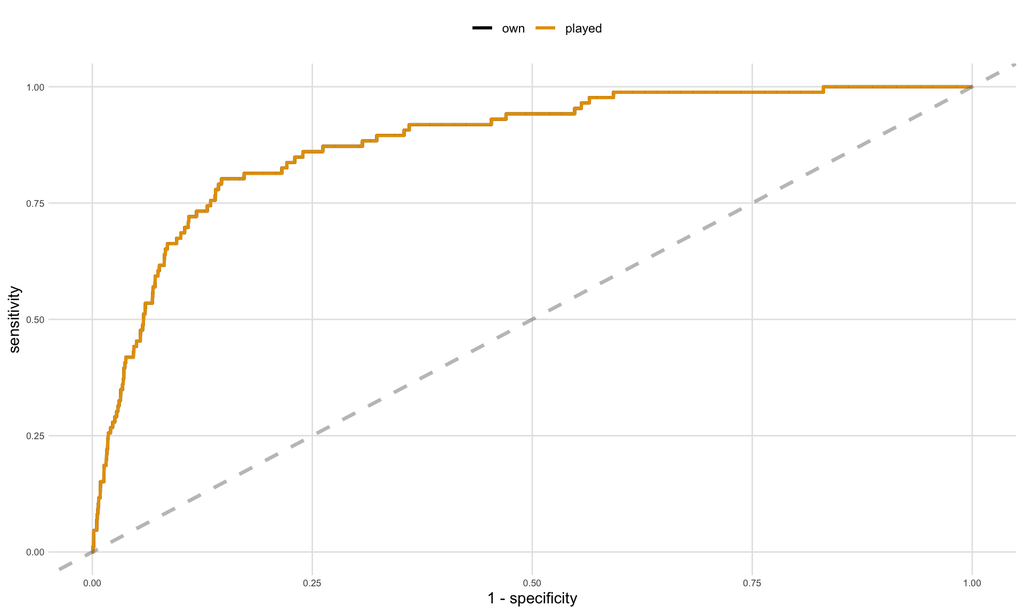

Another way to think about the model performance is to view its lift, or its ability to detect the positive outcomes over that of a null model. High lift indicates the model can much more quickly find all of the positive outcomes (in this case, games owned or played by the user), while a model with no lift is no better than random guessing.

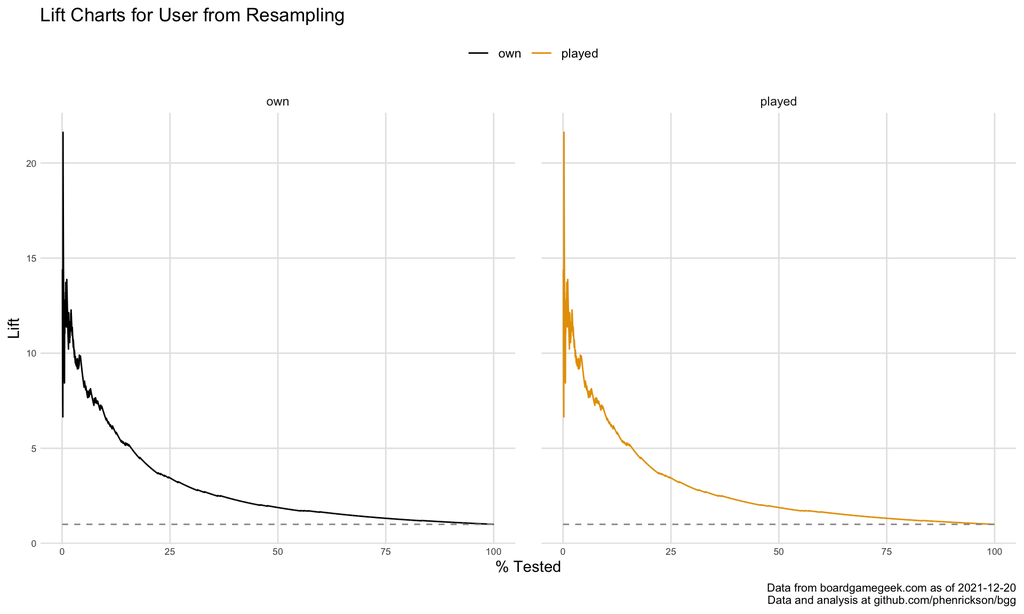

## 3.3 Most and Least Likely Games

What games does the model think mathyvds is **most likely to own** that are **not** in their collection?

| username | yearpublished | game_id | name | pred_own | actual_own |
| --- | --- | --- | --- | --- | --- |
| mathyvds | 2018 | 244711 | Newton | 0.79 | 0 |
| mathyvds | 2019 | 283863 | The Magnificent | 0.77 | 0 |
| mathyvds | 2018 | 258444 | Gingerbread House | 0.65 | 0 |
| mathyvds | 2018 | 205896 | Rising Sun | 0.63 | 0 |
| mathyvds | 2019 | 276025 | Maracaibo | 0.55 | 0 |

What games does the model think mathyvds is **least likely to own** that **are** in their collection?

| username | yearpublished | game_id | name | pred_own | actual_own |
| --- | --- | --- | --- | --- | --- |
| mathyvds | 2019 | 268864 | Undaunted: Normandy | 0 | 1 |
| mathyvds | 2018 | 247367 | Air, Land & Sea | 0 | 1 |
| mathyvds | 2014 | 165722 | KLASK | 0 | 1 |
| mathyvds | 2018 | 239188 | Chronicles of Crime | 0 | 1 |
| mathyvds | 2016 | 188866 | Awkward Guests | 0 | 1 |

## 3.4 Top Games by Year

Top 25 games most likely to be owned by the user in each year, highlighting in blue the games that the user has owned/played.

| rank | 2011 | 2012 | 2013 | 2014 | 2015 | 2016 | 2017 | 2018 | 2019 |
| --- | --- | --- | --- | --- | --- | --- | --- | --- | --- |
| 1 | Takenoko | The Manhattan Project | Lewis & Clark: The Expedition | Patchwork | The Voyages of Marco Polo | When I Dream | Gloomhaven | Newton | The Magnificent |
| 2 | Mundus Novus | Suburbia | Legacy: The Testament of Duke de Crecy | Splendor | Grand Austria Hotel | Inis | Paper Tales | Gingerbread House | Maracaibo |
| 3 | Village | Targi | Sushi Go! | Imperial Settlers | Mysterium | Agricola (Revised Edition) | Harvest Dice | Rising Sun | Clank!: Legacy – Acquisitions Incorporated |
| 4 | Discworld: Ankh-Morpork | Kairo | Impulse | Deception: Murder in Hong Kong | 504 | 13 Days: The Cuban Missile Crisis | Bunny Kingdom | Decrypto | Amul |
| 5 | Principato | Smash Up | Concept | La Granja | Blood Rage | Yokohama | Altiplano | Shadows: Amsterdam | Chai |
| 6 | Nightfall | Seasons | Patchistory | Five Tribes | The Pursuit of Happiness | Terraforming Mars | Tybor the Builder | Century: Eastern Wonders | Barrage |
| 7 | Mage Knight Board Game | Keyflower | Prosperity | Istanbul | FUSE | Codenames: Pictures | The Quest for El Dorado | Coimbra | Era: Medieval Age |
| 8 | Dungeon Fighter | Terra Mystica | Room 25 | Alchemists | The Game | Beyond Baker Street | Smash Up: What Were We Thinking? | Underwater Cities | Tiny Towns |
| 9 | Rumble in the House | Robinson Crusoe: Adventures on the Cursed Island | Bomb Squad | Abyss | The Bloody Inn | Agricola: Family Edition | Photosynthesis | Everdell | Yukon Airways |
| 10 | Tragedy Looper | Space Cadets | The Little Prince: Make Me a Planet | Camel Up | The King Is Dead | Islebound | Clans of Caledonia | Cosmic Run: Regeneration | Ragusa |
| 11 | Undermining | Yedo | Tales & Games: The Three Little Pigs | Medieval Academy | Discoveries: The Journals of Lewis & Clark | Honshū | Century: Spice Road | Blue Lagoon | It's a Wonderful World |
| 12 | Tales & Games: The Hare & the Tortoise | Lords of Waterdeep | Concordia | Port Royal | Brick Party | Clank!: A Deck-Building Adventure | Codenames: Duet | Smash Up: Oops, You Did It Again | Marco Polo II: In the Service of the Khan |
| 13 | Ora et Labora | Kemet | Glass Road | Castles of Mad King Ludwig | Mombasa | Hit Z Road | Breaking Bad: The Board Game | Azul: Stained Glass of Sintra | Circadians: First Light |
| 14 | King of Tokyo | Il Vecchio | Cardline: Globetrotter | Witness | Codenames | Kanagawa | Pulsar 2849 | Sprawlopolis | Wingspan |
| 15 | The City | Love Letter | Circus Train (Second Edition) | Gaïa | Trambahn | Sushi Go Party! | Gaia Project | Treasure Island | Naga Raja |
| 16 | A Few Acres of Snow | Ginkgopolis | Smash Up: Awesome Level 9000 | Sheep & Thief | Haspelknecht | Junk Art | Codenames: Disney – Family Edition | Hokkaido | Minecraft: Builders & Biomes |
| 17 | Streams | Rent a Hero | The Ravens of Thri Sahashri | Spurs: A Tale in the Old West | Far Space Foundry | Imhotep | The Shipwreck Arcana | Duelosaur Island | Queenz: To Bee or Not to Bee |
| 18 | The Gnomes of Zavandor | Agricola: All Creatures Big and Small | Pathfinder Adventure Card Game: Rise of the Runelords – Base Set | Smash Up: Monster Smash | Raiders of the North Sea | Kingdomino | Fog of Love | Kero | The Isle of Cats |
| 19 | Ninjato | Clash of Cultures | Tash-Kalar: Arena of Legends | Spyfall | Pandemic Legacy: Season 1 | Codenames: Deep Undercover | Pandemic Legacy: Season 2 | Reykholt | Century: A New World |
| 20 | Pergamon: Second Edition | Rumble in the Dungeon | Salmon Run | Colt Express | New York 1901 | Broom Service: The Card Game | Clank! In! Space!: A Deck-Building Adventure | Luxor | Ecos: First Continent |
| 21 | Mondo | Noah | UGO! | Praetor | Dale of Merchants | The Networks | Mountains of Madness | Cahoots | Sierra West |
| 22 | Ascension: Storm of Souls | Tzolk'in: The Mayan Calendar | The Phantom Society | Shipwrights of the North Sea | Oh My Goods! | La Granja: No Siesta | Summit: The Board Game | 8Bit Box | Pipeline |
| 23 | Nightfall: Martial Law | Milestones | Cappuccino | Dragon Run | Between Two Cities | Dream Home | Downforce | Micropolis | Watergate |
| 24 | Sekigahara: The Unification of Japan | Qin | Mush! Mush!: Snow Tails 2 | Yardmaster Express | Tales & Games: Little Red Riding Hood | Captain Sonar | Calimala | Architects of the West Kingdom | Noctiluca |
| 25 | Ascension: Return of the Fallen | Zombicide | Caverna: The Cave Farmers | Smash Up: Science Fiction Double Feature | Smash Up: Pretty Pretty Smash Up | The Oregon Trail Card Game | Smash Up: Big in Japan | Pandemic: Fall of Rome | One Key |

## 3.5 Interactive Predictions from Resampling

Interactive table for predictions from resampling.

|  | username | yearpublished | rank | game_id | name | pred_played | pred_own | actual_played | actual_own |
| --- | --- | --- | --- | --- | --- | --- | --- | --- | --- |
| 1 | mathyvds | 1900 | 247 | 10799 | Old Maid | 0.05 | 0.05 | 0 | 0 |
| 2 | mathyvds | 1900 | 905 | 11670 | The Game of Authors | 0.02 | 0.02 | 0 | 0 |
| 3 | mathyvds | 1900 | 1156 | 1602 | The Royal Game of Ur | 0.01 | 0.01 | 0 | 0 |
| 4 | mathyvds | 1900 | 2041 | 38950 | Halma | 0.01 | 0.01 | 0 | 0 |
| 5 | mathyvds | 1900 | 2809 | 15878 | Rummy | 0.01 | 0.01 | 0 | 0 |
| 6 | mathyvds | 1900 | 2963 | 2136 | Pachisi | 0.01 | 0.01 | 0 | 0 |
| 7 | mathyvds | 1900 | 2965 | 2386 | Chinese Checkers | 0.01 | 0.01 | 0 | 0 |
| 8 | mathyvds | 1900 | 2972 | 5432 | Chutes and Ladders | 0.01 | 0.01 | 0 | 0 |
| 9 | mathyvds | 1900 | 3065 | 9364 | Doppelkopf | 0.01 | 0.01 | 0 | 0 |
| 10 | mathyvds | 1900 | 3102 | 2785 | Game of Goose | 0.01 | 0.01 | 0 | 0 |

[output cut: 7426 more lines]

# 4 Validating the Model on 2020

How well did a model trained on a user’s collection through 2019 perform in predicting games for the user from 2020?

| username | outcome_type | yearpublished | .metric | .estimator | .estimate |
| --- | --- | --- | --- | --- | --- |
| mathyvds | own | 2020 | roc_auc | binary | 0.79 |
| mathyvds | played | 2020 | roc_auc | binary | 0.79 |

Table of top 25 games from 2020, highlighting games that the user owns.

| username | yearpublished | game_id | name | pred_own | pred_played | actual_own | actual_played |
| --- | --- | --- | --- | --- | --- | --- | --- |
| mathyvds | 2020 | 184267 | On Mars | 0.74 | 0.74 | 0 | 0 |
| mathyvds | 2020 | 307844 | Atheneum: Mystic Library | 0.53 | 0.53 | 0 | 0 |
| mathyvds | 2020 | 320819 | Dinner in Paris | 0.47 | 0.47 | 0 | 0 |
| mathyvds | 2020 | 300322 | Hallertau | 0.44 | 0.44 | 0 | 0 |
| mathyvds | 2020 | 291457 | Gloomhaven: Jaws of the Lion | 0.26 | 0.26 | 0 | 0 |
| mathyvds | 2020 | 311193 | Anno 1800 | 0.26 | 0.26 | 0 | 0 |
| mathyvds | 2020 | 316377 | 7 Wonders (Second Edition) | 0.15 | 0.15 | 0 | 0 |
| mathyvds | 2020 | 256317 | Guild Master | 0.13 | 0.13 | 0 | 0 |
| mathyvds | 2020 | 301716 | Glasgow | 0.13 | 0.13 | 0 | 0 |
| mathyvds | 2020 | 297204 | Traintopia | 0.12 | 0.12 | 0 | 0 |
| mathyvds | 2020 | 245658 | Unicorn Fever | 0.11 | 0.11 | 0 | 0 |
| mathyvds | 2020 | 299592 | Beez | 0.11 | 0.11 | 0 | 0 |
| mathyvds | 2020 | 288169 | The Fox in the Forest Duet | 0.10 | 0.10 | 0 | 0 |
| mathyvds | 2020 | 296151 | Viscounts of the West Kingdom | 0.10 | 0.10 | 0 | 0 |
| mathyvds | 2020 | 301880 | Raiders of Scythia | 0.09 | 0.09 | 0 | 0 |
| mathyvds | 2020 | 299074 | Space Battle Lunchtime Card Game | 0.08 | 0.08 | 0 | 0 |
| mathyvds | 2020 | 301767 | Mysterium Park | 0.08 | 0.08 | 0 | 0 |
| mathyvds | 2020 | 308765 | Praga Caput Regni | 0.08 | 0.08 | 0 | 0 |
| mathyvds | 2020 | 319966 | The King Is Dead: Second Edition | 0.08 | 0.08 | 0 | 0 |
| mathyvds | 2020 | 289939 | Goblin Teeth | 0.07 | 0.07 | 0 | 0 |
| mathyvds | 2020 | 292333 | Cowboys II: Cowboys & Indians Edition | 0.07 | 0.07 | 0 | 0 |
| mathyvds | 2020 | 293296 | Splendor: Marvel | 0.07 | 0.07 | 0 | 0 |
| mathyvds | 2020 | 298572 | Cosmic Encounter Duel | 0.07 | 0.07 | 0 | 0 |
| mathyvds | 2020 | 300442 | Trekking the World | 0.07 | 0.07 | 0 | 0 |
| mathyvds | 2020 | 302465 | Obsidia | 0.07 | 0.07 | 0 | 0 |

# 5 Predicting Upcoming Games (2020 and On) for **mathyvds**

Examine the top games for the test set.

| username | yearpublished | game_id | name | rank | own | played |
| --- | --- | --- | --- | --- | --- | --- |
| mathyvds | 2020 | 184267 | On Mars | 1 | 0.74 | 0.74 |
| mathyvds | 2020 | 307844 | Atheneum: Mystic Library | 2 | 0.53 | 0.53 |
| mathyvds | 2020 | 320819 | Dinner in Paris | 3 | 0.47 | 0.47 |
| mathyvds | 2020 | 300322 | Hallertau | 4 | 0.44 | 0.44 |
| mathyvds | 2020 | 311193 | Anno 1800 | 5 | 0.26 | 0.26 |
| mathyvds | 2020 | 291457 | Gloomhaven: Jaws of the Lion | 6 | 0.26 | 0.26 |
| mathyvds | 2020 | 316377 | 7 Wonders (Second Edition) | 7 | 0.15 | 0.15 |
| mathyvds | 2020 | 256317 | Guild Master | 8 | 0.13 | 0.13 |
| mathyvds | 2020 | 301716 | Glasgow | 9 | 0.13 | 0.13 |
| mathyvds | 2020 | 297204 | Traintopia | 10 | 0.12 | 0.12 |
| mathyvds | 2020 | 299592 | Beez | 11 | 0.11 | 0.11 |
| mathyvds | 2020 | 245658 | Unicorn Fever | 12 | 0.11 | 0.11 |
| mathyvds | 2020 | 288169 | The Fox in the Forest Duet | 13 | 0.10 | 0.10 |
| mathyvds | 2020 | 296151 | Viscounts of the West Kingdom | 14 | 0.10 | 0.10 |
| mathyvds | 2020 | 301880 | Raiders of Scythia | 15 | 0.09 | 0.09 |
| mathyvds | 2020 | 301767 | Mysterium Park | 16 | 0.08 | 0.08 |
| mathyvds | 2020 | 299074 | Space Battle Lunchtime Card Game | 17 | 0.08 | 0.08 |
| mathyvds | 2020 | 308765 | Praga Caput Regni | 18 | 0.08 | 0.08 |
| mathyvds | 2020 | 319966 | The King Is Dead: Second Edition | 19 | 0.08 | 0.08 |
| mathyvds | 2020 | 289939 | Goblin Teeth | 20 | 0.07 | 0.07 |
| mathyvds | 2020 | 298572 | Cosmic Encounter Duel | 21 | 0.07 | 0.07 |
| mathyvds | 2020 | 300442 | Trekking the World | 22 | 0.07 | 0.07 |
| mathyvds | 2020 | 302465 | Obsidia | 23 | 0.07 | 0.07 |
| mathyvds | 2020 | 292333 | Cowboys II: Cowboys & Indians Edition | 24 | 0.07 | 0.07 |
| mathyvds | 2020 | 293296 | Splendor: Marvel | 25 | 0.07 | 0.07 |
| mathyvds | 2021 | 343905 | Boonlake | 1 | 0.65 | 0.65 |
| mathyvds | 2021 | 291859 | Riftforce | 2 | 0.49 | 0.49 |
| mathyvds | 2021 | 319999 | Dungeon Decorators | 3 | 0.35 | 0.35 |
| mathyvds | 2021 | 298102 | Roll Camera!: The Filmmaking Board Game | 4 | 0.30 | 0.30 |
| mathyvds | 2021 | 342942 | Ark Nova | 5 | 0.24 | 0.24 |
| mathyvds | 2021 | 305761 | Whale Riders | 6 | 0.21 | 0.21 |
| mathyvds | 2021 | 319792 | Fly-A-Way | 7 | 0.15 | 0.15 |
| mathyvds | 2021 | 333553 | For the King (and Me) | 8 | 0.13 | 0.13 |
| mathyvds | 2021 | 282776 | Tumble Town | 9 | 0.12 | 0.12 |
| mathyvds | 2021 | 332944 | Sobek: 2 Players | 10 | 0.12 | 0.12 |
| mathyvds | 2021 | 285967 | Ankh: Gods of Egypt | 11 | 0.11 | 0.11 |
| mathyvds | 2021 | 320992 | The Specialists | 12 | 0.11 | 0.11 |
| mathyvds | 2021 | 310873 | Carnegie | 13 | 0.11 | 0.11 |
| mathyvds | 2021 | 299684 | Khôra: Rise of an Empire | 14 | 0.11 | 0.11 |
| mathyvds | 2021 | 252752 | Genotype: A Mendelian Genetics Game | 15 | 0.10 | 0.10 |
| mathyvds | 2021 | 300217 | Merchants of the Dark Road | 16 | 0.10 | 0.10 |
| mathyvds | 2021 | 249277 | Brazil: Imperial | 17 | 0.10 | 0.10 |
| mathyvds | 2021 | 344408 | Full Throttle! | 18 | 0.09 | 0.09 |
| mathyvds | 2021 | 291847 | Mantis Falls | 19 | 0.08 | 0.08 |
| mathyvds | 2021 | 309408 | Arcana Rising | 20 | 0.07 | 0.07 |
| mathyvds | 2021 | 334644 | Nicodemus | 21 | 0.07 | 0.07 |
| mathyvds | 2021 | 298069 | Cubitos | 22 | 0.07 | 0.07 |
| mathyvds | 2021 | 344277 | Corrosion | 23 | 0.07 | 0.07 |
| mathyvds | 2021 | 340041 | Kingdomino Origins | 24 | 0.07 | 0.07 |
| mathyvds | 2021 | 324242 | Sheepy Time | 25 | 0.06 | 0.06 |
| mathyvds | 2022 | 331106 | The Witcher: Old World | 1 | 0.31 | 0.31 |
| mathyvds | 2022 | 334065 | Verdant | 2 | 0.17 | 0.17 |
| mathyvds | 2022 | 317511 | Tindaya | 3 | 0.15 | 0.15 |
| mathyvds | 2022 | 336986 | Flamecraft | 4 | 0.12 | 0.12 |
| mathyvds | 2022 | 304051 | Creature Comforts | 5 | 0.12 | 0.12 |
| mathyvds | 2022 | 295374 | Long Shot: The Dice Game | 6 | 0.10 | 0.10 |
| mathyvds | 2022 | 295770 | Frosthaven | 7 | 0.09 | 0.09 |
| mathyvds | 2022 | 305096 | Endless Winter: Paleoamericans | 8 | 0.05 | 0.05 |
| mathyvds | 2022 | 322289 | Darwin's Journey | 9 | 0.04 | 0.04 |
| mathyvds | 2022 | 319807 | Shogun no Katana | 10 | 0.04 | 0.04 |
| mathyvds | 2022 | 335427 | Wild: Serengeti | 11 | 0.03 | 0.03 |
| mathyvds | 2022 | 326945 | Castles of Mad King Ludwig: Collector's Edition | 12 | 0.03 | 0.03 |
| mathyvds | 2022 | 345868 | Federation | 13 | 0.03 | 0.03 |
| mathyvds | 2022 | 280726 | Legacies | 14 | 0.03 | 0.03 |
| mathyvds | 2022 | 305462 | The Age of Atlantis | 15 | 0.03 | 0.03 |
| mathyvds | 2022 | 324090 | Scarface 1920 | 16 | 0.03 | 0.03 |
| mathyvds | 2022 | 312959 | Rallyman: DIRT | 17 | 0.03 | 0.03 |
| mathyvds | 2022 | 322589 | Zapotec | 18 | 0.02 | 0.02 |
| mathyvds | 2022 | 299106 | Fractal: Beyond the Void | 19 | 0.02 | 0.02 |
| mathyvds | 2022 | 322524 | Bardsung | 20 | 0.02 | 0.02 |
| mathyvds | 2022 | 338067 | 6: Siege – The Board Game | 21 | 0.02 | 0.02 |
| mathyvds | 2022 | 273814 | Deliverance | 22 | 0.02 | 0.02 |
| mathyvds | 2022 | 342246 | Feuding Foodies | 23 | 0.02 | 0.02 |
| mathyvds | 2022 | 299594 | Megapulse | 24 | 0.02 | 0.02 |
| mathyvds | 2022 | 348463 | ECO: Coral Reef | 25 | 0.02 | 0.02 |

## 5.1 Interactive Table for Upcoming Games 2020 and On

|  | username | yearpublished | game_id | name | rank | own | played |
| --- | --- | --- | --- | --- | --- | --- | --- |
| 1 | mathyvds | 2020 | 184267 | On Mars | 1 | 0.74 | 0.74 |
| 2 | mathyvds | 2021 | 343905 | Boonlake | 2 | 0.65 | 0.65 |
| 3 | mathyvds | 2020 | 307844 | Atheneum: Mystic Library | 3 | 0.53 | 0.53 |
| 4 | mathyvds | 2021 | 291859 | Riftforce | 4 | 0.49 | 0.49 |
| 5 | mathyvds | 2020 | 320819 | Dinner in Paris | 5 | 0.47 | 0.47 |
| 6 | mathyvds | 2020 | 300322 | Hallertau | 6 | 0.44 | 0.44 |
| 7 | mathyvds | 2021 | 319999 | Dungeon Decorators | 7 | 0.35 | 0.35 |
| 8 | mathyvds | 2022 | 331106 | The Witcher: Old World | 8 | 0.31 | 0.31 |
| 9 | mathyvds | 2021 | 298102 | Roll Camera!: The Filmmaking Board Game | 9 | 0.3 | 0.3 |
| 10 | mathyvds | 2020 | 311193 | Anno 1800 | 10 | 0.26 | 0.26 |

[output cut: 1627 more lines]